# 제 9강: 통계적 토대

데이터과학 입문

Author

Affiliation

원중호

서울대학교 통계학과

Published

April 2026

## 시작하기 전에

다음의 패키지가 설치되어 있지 않으면 설치한다.

**R**

```r
# install.packages("tidyverse")
# install.packages("mdsr")
# install.packages("nycflights13")
library(tidyverse)
library(mdsr)
library(nycflights13)
```

**Python**

```python
# conda install session-info
# conda install polars
# conda install plotnine
# conda install statsmodels
import session_info
import zipfile
import io
import polars as pl
from plotnine import *
import statsmodels

session_info.show()
```

```
-----
plotnine            0.15.3
polars              1.38.1
session_info        1.0.0
statsmodels         0.14.6
-----
Python 3.12.12 | packaged by conda-forge | (main, Jan 27 2026, 00:04:03) [Clang 19.1.7 ]
macOS-26.2-arm64-arm-64bit
-----
Session information updated at 2026-04-20 02:08
```

## 들어가며

- 데이터과학의 궁극적 목표: 데이터에서 의미 추출
  - 랭글링: 데이터를 해석하기 쉽도록 사례와 변수를 재구성
  - 시각화: 의미를 탐색할 수 있도록 사람의 마음과 데이터 연결
- 시각화와 인간의 시각적 인지 능력
  - 인간은 임의의 노이즈에 의해 부분적으로 가려져 있어도 패턴을 보는 데 매우 능숙
  - 패턴이 없는 경우에도 패턴을 보는 데 매우 능숙 — 노이즈에 나타나는 우연적 패턴에 쉽게 현혹 (별자리?)
- 통계적 방법
  - 패턴이 강하고 견고해서 단순한 우연이 아니라고 확신할 수 있을 때 식별
  - 통계적 방법은 패턴과 그 강도를 정량화
  - 복잡하거나 다면적이어서 시각적으로 확인하기 어려운 패턴을 찾는 데도 매우 중요

# 표본과 모집단

## 표본과 모집단

- 이전 장에서는 데이터를 고정된 것으로 간주
- 통계학에서는 우리가 가지고 있는 데이터는 고정되어 있지만 방법론은 훨씬 더 큰 잠재적 사례 집합(모집단)에서 표본을 추출한다고 가정
- 모집단에서 추출되었을 수 있는 다른 표본을 상상
- 모집단에서 측정할 수 있는 추가 변수가 있었을 수도 있다고 상상
  - 이 변수와 관련하여 나타나는 모든 패턴은 무작위적이고 우연적인 것이어야 한다
- 도구: 확률

## 모집단에서의 표본 추출

- 뉴욕에 거주하는 사람의 샌프란시스코 출장을 위한 출장 계획 세우기
  - 특정 시각에 회의가 있다고 가정

> 이 시각 보다 얼마나 일찍 도착해야 항공편 지연으로 인해 회의에 늦지 않을 수 있을까?
- `nycflights13` 패키지의 336,776개 항공편을 모집단으로 가정
- 샌프란시스코 공항(SFO)로 들어오는 항공편의 모집단에서 샘플을 추출하여 수집된 데이터(표본)를 기반으로 출장 계획을 세우는 상황을 시뮬레이션 (표본 크기 $n$=25)

**R**

```r
SF <- flights %>%
  filter(dest == "SFO", !is.na(arr_delay))
set.seed(101)
sf_25 <- SF %>%
  slice_sample(n = 25)
```

**Python**

```python
zip_path = "./data/ch05_data.zip"

with zipfile.ZipFile(zip_path, 'r') as z:
    with z.open("flights.csv") as f:
        # Pass the null_values parameter to handle "NA" strings
        flights = pl.read_csv(
            f.read(),
            null_values="NA",
            infer_schema_length=10000  # Help Polars guess types more accurately
        )

SF = (
    flights
    .filter(
        (pl.col("dest") == "SFO") &
        (pl.col("arr_delay").is_not_null())
    )
)
sf_25 = SF.sample(n=25, seed=101)
print(sf_25)
```

```
shape: (25, 19)
┌──────┬───────┬─────┬──────────┬───┬──────────┬──────┬────────┬─────────────────────┐
│ year ┆ month ┆ day ┆ dep_time ┆ … ┆ distance ┆ hour ┆ minute ┆ time_hour           │
│ ---  ┆ ---   ┆ --- ┆ ---      ┆   ┆ ---      ┆ ---  ┆ ---    ┆ ---                 │
│ i64  ┆ i64   ┆ i64 ┆ i64      ┆   ┆ i64      ┆ i64  ┆ i64    ┆ str                 │
╞══════╪═══════╪═════╪══════════╪═══╪══════════╪══════╪════════╪═════════════════════╡
│ 2013 ┆ 6     ┆ 28  ┆ 1015     ┆ … ┆ 2586     ┆ 8    ┆ 53     ┆ 2013-06-28 08:00:00 │
│ 2013 ┆ 2     ┆ 27  ┆ 927      ┆ … ┆ 2565     ┆ 8    ┆ 30     ┆ 2013-02-27 08:00:00 │
│ 2013 ┆ 5     ┆ 4   ┆ 921      ┆ … ┆ 2565     ┆ 9    ┆ 25     ┆ 2013-05-04 09:00:00 │
│ 2013 ┆ 7     ┆ 19  ┆ 556      ┆ … ┆ 2586     ┆ 6    ┆ 1      ┆ 2013-07-19 06:00:00 │
│ 2013 ┆ 8     ┆ 23  ┆ 1821     ┆ … ┆ 2565     ┆ 18   ┆ 22     ┆ 2013-08-23 18:00:00 │
│ …    ┆ …     ┆ …   ┆ …        ┆ … ┆ …        ┆ …    ┆ …      ┆ …                   │
│ 2013 ┆ 4     ┆ 19  ┆ 726      ┆ … ┆ 2586     ┆ 7    ┆ 30     ┆ 2013-04-19 07:00:00 │
│ 2013 ┆ 8     ┆ 3   ┆ 1528     ┆ … ┆ 2586     ┆ 15   ┆ 30     ┆ 2013-08-03 15:00:00 │
│ 2013 ┆ 10    ┆ 2   ┆ 2043     ┆ … ┆ 2586     ┆ 20   ┆ 25     ┆ 2013-10-02 20:00:00 │
│ 2013 ┆ 10    ┆ 23  ┆ 1638     ┆ … ┆ 2565     ┆ 16   ┆ 42     ┆ 2013-10-23 16:00:00 │
│ 2013 ┆ 1     ┆ 18  ┆ 1059     ┆ … ┆ 2565     ┆ 11   ┆ 0      ┆ 2013-01-18 11:00:00 │
└──────┴───────┴─────┴──────────┴───┴──────────┴──────┴────────┴─────────────────────┘
```

- 간단한 방법: 가장 긴 항공편 지연을 찾아 이 지연에 대처할 수 있도록 여행 일정 조정

**R**

```r
sf25skim <- sf_25 %>% skim(arr_delay)
sf25skim
```

**Variable type: numeric**

| var | n | na | mean | sd | p0 | p25 | p50 | p75 | p100 |
| --- | --- | --- | --- | --- | --- | --- | --- | --- | --- |
| arr_delay | 25 | 0 | 0.12 | 29.79 | -38 | -23 | -5 | 14 | 103 |

**Python**

```python
sf_25.select("arr_delay").describe()
```

shape: (9, 2)

| statistic str | arr_delay f64 |
| --- | --- |
| "count" | 25.0 |
| "null_count" | 0.0 |
| "mean" | 0.96 |
| "std" | 34.152208 |
| "min" | -44.0 |
| "25%" | -20.0 |
| "50%" | -13.0 |
| "75%" | 10.0 |
| "max" | 93.0 |

- 최대 지연은 103분. 이만큼 일찍 도착하면 될까?

**R**

```r
SFskim <- SF %>% skim(arr_delay)
SFskim
```

**Variable type: numeric**

| var | n | na | mean | sd | p0 | p25 | p50 | p75 | p100 |
| --- | --- | --- | --- | --- | --- | --- | --- | --- | --- |
| arr_delay | 13173 | 0 | 2.67 | 47.67 | -86 | -23 | -8 | 12 | 1007 |

**Python**

```python
SF.select("arr_delay").describe()
```

shape: (9, 2)

| statistic str | arr_delay f64 |
| --- | --- |
| "count" | 13173.0 |
| "null_count" | 0.0 |
| "mean" | 2.672892 |
| "std" | 47.670642 |
| "min" | -86.0 |
| "25%" | -23.0 |
| "50%" | -8.0 |
| "75%" | 12.0 |
| "max" | 1007.0 |

- 모집단에서의 최대 지연 시간은 1007분.
- 17시간 정도 일찍 도착?
  - 하루를 더 여행하면 숙박, 식사 등의 추가비용 발생
  - 1007분 이상 지연이 발생하지 않는다는 보장 없음
- 합리적인 계획: 비용 절약과 지각할 가능성을 절충 — 100번 같은 출장을 간다면 그 중 2번만 지각해도 괜찮음

**R**

```r
  sf_25 %>% summarize(q98 = quantile(arr_delay, p = 0.98))
```

```
# A tibble: 1 × 1
    q98
  <dbl>
1  67.5
```

**Python**

```python
print(
  sf_25.select(
    pl.col("arr_delay").quantile(0.98).alias("q98")
  )
)
```

```
shape: (1, 1)
┌──────┐
│ q98  │
│ ---  │
│ f64  │
╞══════╡
│ 93.0 │
└──────┘
```

> 90분 일찍 도착하는 계획을 세웠다면 회의에 2% 이하의 확률로만 지각하겠다는 의도를 달성하는 데 얼마나 효과가 있었을까?

**R**

```r
SF %>%
  group_by(arr_delay < 90) %>%
  count() %>%
  mutate(pct = n / nrow(SF))
```

```
# A tibble: 2 × 3
# Groups:   arr_delay < 90 [2]
  `arr_delay < 90`     n    pct
  <lgl>            <int>  <dbl>
1 FALSE              640 0.0486
2 TRUE             12533 0.951
```

**Python**

```python
print(
    SF
    .group_by(
        (pl.col("arr_delay") < 90).alias("on_time_ish")
    )
    .len() # Replicates count()
    .with_columns(
        (pl.col("len") / SF.height).alias("pct")
    )
)
```

```
shape: (2, 3)
┌─────────────┬───────┬──────────┐
│ on_time_ish ┆ len   ┆ pct      │
│ ---         ┆ ---   ┆ ---      │
│ bool        ┆ u32   ┆ f64      │
╞═════════════╪═══════╪══════════╡
│ false       ┆ 640   ┆ 0.048584 │
│ true        ┆ 12533 ┆ 0.951416 │
└─────────────┴───────┴──────────┘
```

- 90분 정책은 훨씬 더 나쁜 5%의 빈도로 목표를 달성하지 못함

> 2%의 확률을 정확하게 맞추려면 정책을 90분에서 어떤 값으로 늘려야 할까?

**R**

```r
SF %>% summarize(q98 = quantile(arr_delay, p = 0.98))
```

```
# A tibble: 1 × 1
    q98
  <dbl>
1   153
```

**Python**

```python
print(
  SF.select(
    pl.col("arr_delay").quantile(0.98).alias("q98")
  )
)
```

```
shape: (1, 1)
┌───────┐
│ q98   │
│ ---   │
│ f64   │
╞═══════╡
│ 153.0 │
└───────┘
```

- 대부분의 실제 환경에서는 모집단 데이터에 접근할 수 없고 표본 데이터만 있을 뿐
- 샘플에서 얻은 결과가 98% 목표를 충족하기에 충분한지 판단하기 위해 샘플을 어떻게 사용할 수 있을까?
- 충분하지 않다면 표본의 크기는 어느 정도여야 만족할 만한 결과를 얻을 수 있을까?

# 표본통계량

## 표본분포

- 항공편 지연 시간 표본의 98백분위수는 (별로 좋지 않은) **통계량**
- 모집단에서 새로운 표본을 추출하는 경우, 새로운 표본의 통계량이 원래 표본에서 계산된 동일한 통계량과 얼마나 유사할까?
- 즉, 모집단에서 크기 $n$인 표본을 여러 번 추출하고 각 표본에 대한 통계량을 계산하면 모든 이들 통계량은 얼마나 유사할까?

**R**

```r
n <- 25
num_trials <- 500
sf_25_means <- 1:num_trials %>%
  map_dfr(
    ~ SF %>%
      slice_sample(n = n) %>%
      summarize(mean_arr_delay = mean(arr_delay))
  ) %>%
  mutate(n = n)

head(sf_25_means)
```

```
# A tibble: 6 × 2
  mean_arr_delay     n
           <dbl> <dbl>
1         -5.92     25
2          9.24     25
3         -6.28     25
4         14.2      25
5         -2.84     25
6          0.600    25
```

**Python**

```python
n = 25
num_trials = 500

sf_25_means = (
    pl.Series("trial", range(num_trials))
    .to_frame()
    .select([
        pl.col("trial").map_elements(
            lambda _: SF.sample(n=n)["arr_delay"].mean(),
            return_dtype=pl.Float64
        ).alias("mean_arr_delay"),
        pl.lit(n).alias("n")
    ])
)

print(sf_25_means.head())
```

```
shape: (5, 2)
┌────────────────┬─────┐
│ mean_arr_delay ┆ n   │
│ ---            ┆ --- │
│ f64            ┆ i32 │
╞════════════════╪═════╡
│ 4.44           ┆ 25  │
│ 1.2            ┆ 25  │
│ -8.6           ┆ 25  │
│ -1.12          ┆ 25  │
│ -8.2           ┆ 25  │
└────────────────┴─────┘
```

**R**

```r
sf_25_means %>% skim(mean_arr_delay)
```

**Variable type: numeric**

| var | n | na | mean | sd | p0 | p25 | p50 | p75 | p100 |
| --- | --- | --- | --- | --- | --- | --- | --- | --- | --- |
| mean_arr_delay | 500 | 0 | 3.09 | 10.16 | -20.12 | -3.72 | 1.54 | 9 | 56.68 |

**Python**

```python
sf_25_means.select("mean_arr_delay").describe()
```

shape: (9, 2)

| statistic str | mean_arr_delay f64 |
| --- | --- |
| "count" | 500.0 |
| "null_count" | 0.0 |
| "mean" | 2.1964 |
| "std" | 9.307298 |
| "min" | -20.84 |
| "25%" | -3.96 |
| "50%" | 1.28 |
| "75%" | 7.8 |
| "max" | 48.48 |

- 평균이 중앙값의 두 배 이상이므로 표본분포가 오른쪽으로 치우쳐(right-skewed) 있음
- 다른 표본통계량

**R**

```r
sf_25_means %>%
  summarize(
    x_bar = mean(mean_arr_delay),
    se = sd(mean_arr_delay)
  ) %>%
  mutate(
    ci_lower = x_bar - 2 * se, # approximately 95% of observations
    ci_upper = x_bar + 2 * se  # are within two standard errors
  )
```

```
# A tibble: 1 × 4
  x_bar    se ci_lower ci_upper
  <dbl> <dbl>    <dbl>    <dbl>
1  3.09  10.2    -17.2     23.4
```

**Python**

```python
print(
    sf_25_means
    .select([
        pl.col("mean_arr_delay").mean().alias("x_bar"),
        pl.col("mean_arr_delay").std().alias("se")
    ])
    .with_columns([
        (pl.col("x_bar") - 2 * pl.col("se")).alias("ci_lower"),
        (pl.col("x_bar") + 2 * pl.col("se")).alias("ci_upper")
    ])
)
```

```
shape: (1, 4)
┌────────┬──────────┬────────────┬───────────┐
│ x_bar  ┆ se       ┆ ci_lower   ┆ ci_upper  │
│ ---    ┆ ---      ┆ ---        ┆ ---       │
│ f64    ┆ f64      ┆ f64        ┆ f64       │
╞════════╪══════════╪════════════╪═══════════╡
│ 2.1964 ┆ 9.307298 ┆ -16.418197 ┆ 20.810997 │
└────────┴──────────┴────────────┴───────────┘
```

## 표본 크기

- 신뢰성 있는 결과를 얻으려면 얼마나 큰 표본이 필요한가?

**R**

```r
n <- 100
sf_100_means <- 1:500 %>%
  map_dfr(
    ~ SF %>%
      slice_sample(n = n) %>%
      summarize(mean_arr_delay = mean(arr_delay))
  ) %>%
  mutate(n = n)
```

**Python**

```python
n = 100
num_trials = 500

sf_100_means = (
    pl.Series("trial", range(num_trials))
    .to_frame()
    .select([
        pl.col("trial").map_elements(
            lambda _: SF.sample(n=n)["arr_delay"].mean(),
            return_dtype=pl.Float64
        ).alias("mean_arr_delay"),
        pl.lit(n).alias("n")
    ])
)
print(sf_100_means.head())
```

```
shape: (5, 2)
┌────────────────┬─────┐
│ mean_arr_delay ┆ n   │
│ ---            ┆ --- │
│ f64            ┆ i32 │
╞════════════════╪═════╡
│ 0.23           ┆ 100 │
│ 0.92           ┆ 100 │
│ -5.03          ┆ 100 │
│ 1.44           ┆ 100 │
│ 8.0            ┆ 100 │
└────────────────┴─────┘
```

**R**

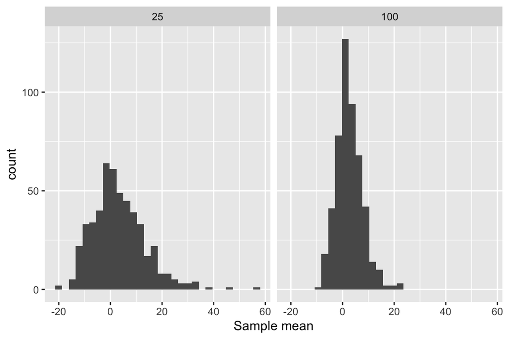

```r
sf_25_means %>%
  bind_rows(sf_100_means) %>%
  ggplot(aes(x = mean_arr_delay)) +
  geom_histogram(bins = 30) +
  facet_grid( ~ n) +
  xlab("Sample mean")
```

**Python**

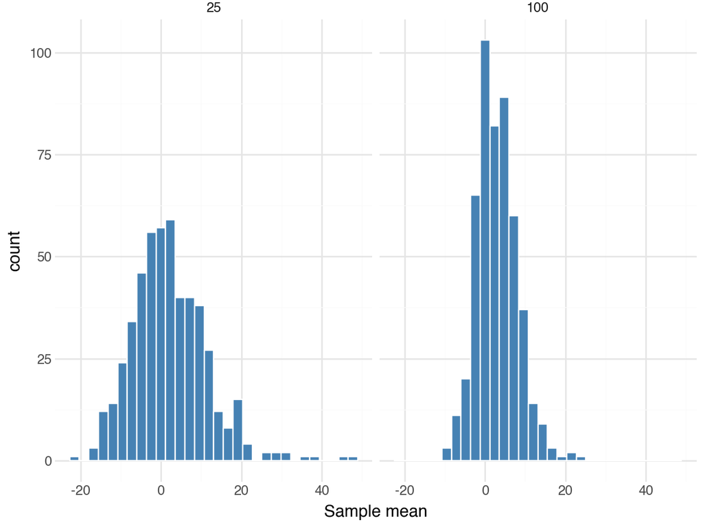

```python
comparison_df = pl.concat([sf_25_means, sf_100_means])
(
    ggplot(comparison_df, aes(x="mean_arr_delay"))
    + geom_histogram(bins=30, fill="steelblue", color="white")
    + facet_grid(". ~ n")  # Syntax for columns: "rows ~ columns" (. means no row facet)
    + xlab("Sample mean")
    + theme_minimal()
).show()
```

- 두 표본분포는 중심은 거의 일치함
- 표본 크기가 클수록 표준 오차가 더 작아짐. 즉, 표본 크기가 클수록 작은 표본 크기보다 더 신뢰할 수 있음
- 표본 크기가 큰 경우, 표본분포의 모양은 종 모양이 되는 경향이 있음

# 부트스트랩

## 재표집과 부트스트랩

- 앞 예제에서는 모집단 데이터에 접근할 수 있었기 때문에 모집단에서 반복적으로 표본을 추출하여 표본분포를 구할 수 있었음
- 현실에서는 전체 모집단이 아닌 하나의 표본만 있음
- 부트스트랩은 모집단에 대한 접근 없이도 표본분포를 근사할 수 있는 통계적 방법
- 표본 자체를 모집단처럼 생각, 복원추출을 통해 “새로운 표본”을 많이 생성, 각 표본마다 통계량 계산
- 표본

**R**

```r
three_flights <- SF %>%
  slice_sample(n = 3, replace = FALSE) %>%
  select(year, month, day, dep_time)
three_flights
```

```
# A tibble: 3 × 4
   year month   day dep_time
  <int> <int> <int>    <int>
1  2013     8     5     1327
2  2013     3     3     1526
3  2013     4    11      728
```

**Python**

```python
three_flights = (
    SF
    .sample(n=3, with_replacement=False)
    .select(["year", "month", "day", "dep_time"])
)
print(three_flights)
```

```
shape: (3, 4)
┌──────┬───────┬─────┬──────────┐
│ year ┆ month ┆ day ┆ dep_time │
│ ---  ┆ ---   ┆ --- ┆ ---      │
│ i64  ┆ i64   ┆ i64 ┆ i64      │
╞══════╪═══════╪═════╪══════════╡
│ 2013 ┆ 5     ┆ 28  ┆ 1924     │
│ 2013 ┆ 8     ┆ 28  ┆ 1520     │
│ 2013 ┆ 5     ┆ 20  ┆ 1830     │
└──────┴───────┴─────┴──────────┘
```

- 재표집

**R**

```r
three_flights %>% slice_sample(n = 3, replace = TRUE)
```

```
# A tibble: 3 × 4
   year month   day dep_time
  <int> <int> <int>    <int>
1  2013     4    11      728
2  2013     3     3     1526
3  2013     8     5     1327
```

**Python**

```python
three_flights.sample(n=3, with_replacement=True, seed=42)
```

shape: (3, 4)

| year i64 | month i64 | day i64 | dep_time i64 |
| --- | --- | --- | --- |
| 2013 | 5 | 20 | 1830 |
| 2013 | 5 | 28 | 1924 |
| 2013 | 5 | 20 | 1830 |

**R**

```r
n <- 200
orig_sample <- SF %>%        # sample
  slice_sample(n = n, replace = TRUE)
# resample
sf_200_bs <- 1:num_trials %>%    # num_trials == 500
  map_dfr(
    ~orig_sample %>%
      slice_sample(n = n, replace = TRUE) %>%
      summarize(mean_arr_delay = mean(arr_delay))
  ) %>%
  mutate(n = n)
# bootstrap statistics
sf_200_bs %>%
  skim(mean_arr_delay)
```

**Variable type: numeric**

| var | n | na | mean | sd | p0 | p25 | p50 | p75 | p100 |
| --- | --- | --- | --- | --- | --- | --- | --- | --- | --- |
| mean_arr_delay | 500 | 0 | 8.52 | 4.04 | -2.04 | 5.79 | 8.42 | 11.28 | 24.11 |

**Python**

```python
n = 200
num_trials = 500

orig_sample = SF.sample(n=n, with_replacement=True)

sf_200_bs = (
    pl.Series("trial", range(num_trials))
    .to_frame()
    .select([
        pl.col("trial").map_elements(
            lambda _: orig_sample.sample(n=n, with_replacement=True)["arr_delay"].mean(),
            return_dtype=pl.Float64
        ).alias("mean_arr_delay"),
        pl.lit(n).alias("n")
    ])
)
sf_200_bs.select("mean_arr_delay").describe()
```

shape: (9, 2)

| statistic str | mean_arr_delay f64 |
| --- | --- |
| "count" | 500.0 |
| "null_count" | 0.0 |
| "mean" | 1.31311 |
| "std" | 3.137972 |
| "min" | -6.82 |
| "25%" | -0.975 |
| "50%" | 1.16 |
| "75%" | 3.385 |
| "max" | 10.45 |

- 이 예제에서는 모집단을 알고 있으므로 부트스트랩 추정량을 크기 $n$=200인 가상의 표본들과 비교

**R**

```r
sf_200_pop <- 1:num_trials %>%
  map_dfr(
    ~SF %>%
      slice_sample(n = n, replace = FALSE) %>%
      summarize(mean_arr_delay = mean(arr_delay))
  ) %>%
  mutate(n = n)

sf_200_pop %>%
  skim(mean_arr_delay)
```

**Variable type: numeric**

| var | n | na | mean | sd | p0 | p25 | p50 | p75 | p100 |
| --- | --- | --- | --- | --- | --- | --- | --- | --- | --- |
| mean_arr_delay | 500 | 0 | 2.67 | 3.3 | -6.24 | 0.38 | 2.5 | 4.9 | 17.21 |

**Python**

```python
n = 200
num_trials = 500

sf_200_pop = (
    pl.Series("trial", range(num_trials))
    .to_frame()
    .select([
        pl.col("trial").map_elements(
            lambda _: SF.sample(n=n, with_replacement=False)["arr_delay"].mean(),
            return_dtype=pl.Float64
        ).alias("mean_arr_delay"),
        pl.lit(n).alias("n")
    ])
)

sf_200_pop.select("mean_arr_delay").describe()
```

shape: (9, 2)

| statistic str | mean_arr_delay f64 |
| --- | --- |
| "count" | 500.0 |
| "null_count" | 0.0 |
| "mean" | 2.88042 |
| "std" | 3.54851 |
| "min" | -6.145 |
| "25%" | 0.425 |
| "50%" | 2.705 |
| "75%" | 5.27 |
| "max" | 15.475 |

- 부트스트랩(`sf_200_bs`)에는 모집단이 사용되지 않고 원 표본만 사용되었다는 점에 주의
- 부트스트랩을 사용하여 계산된 표준오차(4.0분)가 모집단에서 반복적으로 표본을 추출하여 계산된 표본분포의 표준 오차(3.3분)에 대한 괜찮은 근사치
- 부트스트랩 분포 = 부트스트랩 통계량의 분포
  - 표본 분포와 정확히 같지는 않지만, 표본 크기가 적당히 크고 부트스트랩 시행 횟수가 충분한 경우 표준 오차 및 분위수 등 중요한 표본 분포의 특성에 수렴 (Efron and Tibshirani 1993).

## 출장 예제

- 크기 $n$=200인 표본으로부터 98백분위를 계산

**R**

```r
orig_sample %>% summarize(q98 = quantile(arr_delay, p = 0.98))
```

```
# A tibble: 1 × 1
    q98
  <dbl>
1  209.
```

**Python**

```python
print(
  orig_sample.select(
    pl.col("arr_delay").quantile(0.98).alias("q98")
  )
)
```

```
shape: (1, 1)
┌───────┐
│ q98   │
│ ---   │
│ f64   │
╞═══════╡
│ 101.0 │
└───────┘
```

- 부트스트랩을 이용하여 신뢰도를 계산

**R**

```r
n <- nrow(orig_sample)
sf_200_bs <- 1:num_trials %>%
  map_dfr(
    ~orig_sample %>%
      slice_sample(n = n, replace = TRUE) %>%
      summarize(q98 = quantile(arr_delay, p = 0.98))
  )
```

**Python**

```python
n = len(orig_sample)
num_trials = 500

sf_200_bs = (
    pl.Series("trial", range(num_trials))
    .to_frame()
    .select([
        pl.col("trial").map_elements(
            lambda _: orig_sample.sample(n=n, with_replacement=True)["arr_delay"].quantile(0.98),
            return_dtype=pl.Float64
        ).alias("q98")
    ])
)
```

**R**

```r
sf_200_bs %>% skim(q98)
```

**Variable type: numeric**

| var | n | na | mean | sd | p0 | p25 | p50 | p75 | p100 |
| --- | --- | --- | --- | --- | --- | --- | --- | --- | --- |
| q98 | 500 | 0 | 206.36 | 57.18 | 75 | 153 | 208.86 | 251.02 | 344.32 |

**Python**

```python
sf_200_bs.select("q98").describe()
```

shape: (9, 2)

| statistic str | q98 f64 |
| --- | --- |
| "count" | 500.0 |
| "null_count" | 0.0 |
| "mean" | 107.522 |
| "std" | 22.667889 |
| "min" | 61.0 |
| "25%" | 96.0 |
| "50%" | 101.0 |
| "75%" | 102.0 |
| "max" | 165.0 |

- 부트스트랩 표준 오차는 약 57분 — 95% 신뢰구간은 대략 206 ± 114분
- 206분 일찍 가기 계획은 그리 좋아 보이지 않음
- 표본 크기를 늘리면 나을까?

**R**

```r
set.seed(1001)
n_large <- 10000
sf_10000_sample <- SF %>%
  slice_sample(n = n_large, replace = FALSE)
sf_10000_sample %>% summarize(q98 = quantile(arr_delay, p = 0.98))
```

```
# A tibble: 1 × 1
    q98
  <dbl>
1  153.
```

```r
sf_10000_bs <- 1:num_trials %>%
  map_dfr(~sf_10000_sample %>%
        slice_sample(n = n_large, replace = TRUE) %>%
        summarize(q98 = quantile(arr_delay, p = 0.98))
  )

sf_10000_bs %>% skim(q98)
```

**Variable type: numeric**

| var | n | na | mean | sd | p0 | p25 | p50 | p75 | p100 |
| --- | --- | --- | --- | --- | --- | --- | --- | --- | --- |
| q98 | 500 | 0 | 153.88 | 4.14 | 139.02 | 151.02 | 153.02 | 156.02 | 169 |

**Python**

```python
n_large = 10000
num_trials = 500

sf_10000_sample = SF.sample(n=n_large, with_replacement=False, seed=1001)
print(
  sf_10000_sample.select(
    pl.col("arr_delay").quantile(0.98).alias("q98")
  )
)
```

```
shape: (1, 1)
┌───────┐
│ q98   │
│ ---   │
│ f64   │
╞═══════╡
│ 151.0 │
└───────┘
```

```python
sf_10000_bs = (
    pl.Series("trial", range(num_trials))
    .to_frame()
    .select([
        pl.col("trial").map_elements(
            lambda _: sf_10000_sample.sample(n=n_large, with_replacement=True)["arr_delay"].quantile(0.98),
            return_dtype=pl.Float64
        ).alias("q98")
    ])
)
sf_10000_bs.select("q98").describe()
```

shape: (9, 2)

| statistic str | q98 f64 |
| --- | --- |
| "count" | 500.0 |
| "null_count" | 0.0 |
| "mean" | 148.978 |
| "std" | 5.470408 |
| "min" | 132.0 |
| "25%" | 147.0 |
| "50%" | 151.0 |
| "75%" | 152.0 |
| "max" | 164.0 |

- 154 ± 8분은 훨씬 좋아 보임
- 데이터가 많을수록 추정량을 모수에 더 가깝게 할 수 있으며, 특히 꼬리 부분의 추정이 더 쉬워짐

# 이상치

## 이상치 식별

- 더 많은 데이터가 도움이 되는 분야 중 하나
- 항공편이 7시간(420분) 이상 지연되는 경우를 극단적인 상황으로 간주해 보자
  - 420분은 자의적인 선택이나 심각한 지연을 나타내는 지표로 유용할 수 있음

**R**

```r
SF %>%
  filter(arr_delay >= 420) %>%
  select(month, day, dep_delay, arr_delay, carrier)
```

```
# A tibble: 7 × 5
  month   day dep_delay arr_delay carrier
  <int> <int>     <dbl>     <dbl> <chr>
1    12     7       374       422 UA
2     7     6       589       561 DL
3     7     7       629       676 VX
4     7     7       653       632 VX
5     7    10       453       445 B6
6     7    10       432       433 VX
7     9    20      1014      1007 AA
```

**Python**

```python
print(
    SF
    .filter(pl.col("arr_delay") >= 420)
    .select(["month", "day", "dep_delay", "arr_delay", "carrier"])
)
```

```
shape: (7, 5)
┌───────┬─────┬───────────┬───────────┬─────────┐
│ month ┆ day ┆ dep_delay ┆ arr_delay ┆ carrier │
│ ---   ┆ --- ┆ ---       ┆ ---       ┆ ---     │
│ i64   ┆ i64 ┆ i64       ┆ i64       ┆ str     │
╞═══════╪═════╪═══════════╪═══════════╪═════════╡
│ 12    ┆ 7   ┆ 374       ┆ 422       ┆ UA      │
│ 7     ┆ 6   ┆ 589       ┆ 561       ┆ DL      │
│ 7     ┆ 7   ┆ 629       ┆ 676       ┆ VX      │
│ 7     ┆ 7   ┆ 653       ┆ 632       ┆ VX      │
│ 7     ┆ 10  ┆ 453       ┆ 445       ┆ B6      │
│ 7     ┆ 10  ┆ 432       ┆ 433       ┆ VX      │
│ 9     ┆ 20  ┆ 1014      ┆ 1007      ┆ AA      │
└───────┴─────┴───────────┴───────────┴─────────┘
```

- 극단적 지연의 대부분이 7월에 발생 (7건 중 5건)
- 가장 빈번한 위반 항공사는 Virgin America (VX).
- “7월에 일찍 도착하고 VX를 피하라.”
- 이상값 자체가 오해의 소지가 있을 수 있음
  - 2013년 뉴욕에서 샌프란시스코로 가는 항공편 중 극히 일부
  - 정시에 회의에 도착하는 데 실패하는 비율을 2%로 낮춘다는 목표에 비하면 아주 작은 부분
  - 2013년 7월 샌프란시스코 공항에서는 아시아나항공 214편의 착륙 사고라는 더욱 드문 사건이 발생

**Note**

- 이상값을 처리하는 방법은 그 원인에 따라 다름
- 데이터 불규칙성이나 오류로 인한 이상값은 수정
- 다른 이상값은 문제에 대한 중요한 직관을 제공할 수 있음
- 명확한 근거가 없는 이상 이상값은 절대 삭제해서는 안 됨
- 이상값이 삭제된 경우에는 이를 명확하게 보고해야 함
- 이상치 제거한 히스토그램

**R**

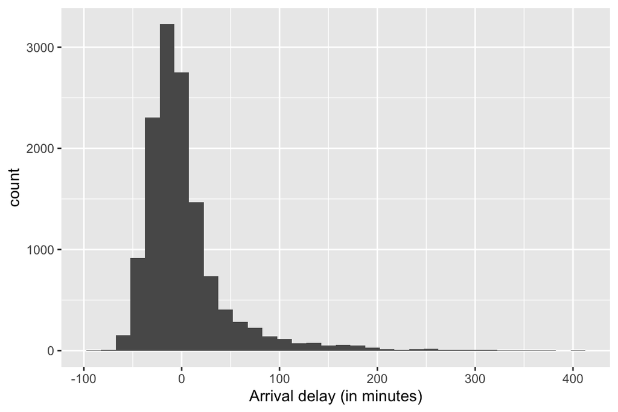

```r
SF %>%
  filter(arr_delay < 420) %>%
  ggplot(aes(arr_delay)) +
  geom_histogram(binwidth = 15) +
  labs(x = "Arrival delay (in minutes)")
```

**Python**

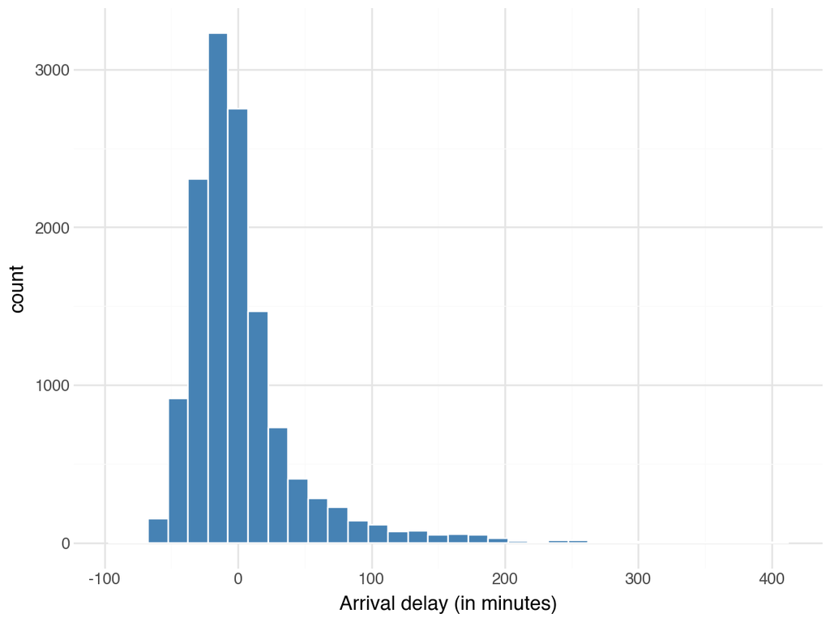

```python
sf_filtered = SF.filter(pl.col("arr_delay") < 420)
(
    ggplot(sf_filtered, aes(x="arr_delay"))
    + geom_histogram(binwidth=15, fill="steelblue", color="white")
    + labs(x="Arrival delay (in minutes)")
    + theme_minimal()
).show()
```

- 대부분의 항공편이 지연 없이 도착하거나 60분 미만의 지연이 발생
- 장시간 지연이 발생할 가능성이 높은 시기를 예측할 수 있는 패턴을 파악할 수 있을까?
- 이상값은 해당 월 또는 항공사가 장시간 지연과 관련이 있을 수 있음을 시사

**R**

```r
SF %>%
  mutate(long_delay = arr_delay > 60) %>%
  group_by(month, long_delay) %>%
  count() %>%
  pivot_wider(names_from = month, values_from = n) %>%
  data.frame()
```

```
  long_delay  X1  X2  X3  X4   X5  X6  X7   X8   X9  X10  X11  X12
1      FALSE 856 741 812 993 1128 980 966 1159 1124 1177 1107 1093
2       TRUE  29  21  61 112   65 209 226   96   65   36   51   66
```

**Python**

```python
print(
    SF
    .with_columns(
        (pl.col("arr_delay") > 60).alias("long_delay")
    )
    .pivot(
        on="month",
        index="long_delay",
        values="arr_delay",
        aggregate_function="count"
    )
)
```

```
shape: (2, 13)
┌────────────┬─────┬──────┬──────┬───┬─────┬─────┬──────┬──────┐
│ long_delay ┆ 1   ┆ 10   ┆ 11   ┆ … ┆ 6   ┆ 7   ┆ 8    ┆ 9    │
│ ---        ┆ --- ┆ ---  ┆ ---  ┆   ┆ --- ┆ --- ┆ ---  ┆ ---  │
│ bool       ┆ u32 ┆ u32  ┆ u32  ┆   ┆ u32 ┆ u32 ┆ u32  ┆ u32  │
╞════════════╪═════╪══════╪══════╪═══╪═════╪═════╪══════╪══════╡
│ false      ┆ 856 ┆ 1177 ┆ 1107 ┆ … ┆ 980 ┆ 966 ┆ 1159 ┆ 1124 │
│ true       ┆ 29  ┆ 36   ┆ 51   ┆ … ┆ 209 ┆ 226 ┆ 96   ┆ 65   │
└────────────┴─────┴──────┴──────┴───┴─────┴─────┴──────┴──────┘
```

- 6월과 7월이 문제

**R**

```r
SF %>%
  mutate(long_delay = arr_delay > 60) %>%
  group_by(carrier, long_delay) %>%
  count() %>%
  pivot_wider(names_from = carrier, values_from = n) %>%
  data.frame()
```

```
  long_delay   AA  B6   DL   UA   VX
1      FALSE 1250 934 1757 6236 1959
2       TRUE  148  86   91  492  220
```

**Python**

```python
print(
    SF
    .with_columns(
        (pl.col("arr_delay") > 60).alias("long_delay")
    )
    .pivot(
        on="carrier",
        index="long_delay",
        values="arr_delay",
        aggregate_function="count"
    )
)
```

```
shape: (2, 6)
┌────────────┬──────┬──────┬──────┬─────┬──────┐
│ long_delay ┆ UA   ┆ DL   ┆ VX   ┆ B6  ┆ AA   │
│ ---        ┆ ---  ┆ ---  ┆ ---  ┆ --- ┆ ---  │
│ bool       ┆ u32  ┆ u32  ┆ u32  ┆ u32 ┆ u32  │
╞════════════╪══════╪══════╪══════╪═════╪══════╡
│ false      ┆ 6236 ┆ 1757 ┆ 1959 ┆ 934 ┆ 1250 │
│ true       ┆ 492  ┆ 91   ┆ 220  ┆ 86  ┆ 148  │
└────────────┴──────┴──────┴──────┴─────┴──────┘
```

- 두 가지 간단한 분석으로 여행자에게 6월과 7월에 더 일찍 도착할 계획을 세우고 SFO로 비행할 항공사로 델타항공(DL)을 고려하도록 조언할 것을 암시

# 통계 모형

## 변동성 설명

- 지금까지의 노력은 항공편마다의 연착 변동성을 일부 설명하려 한 것
- 통계 모형은 변수를 서로 연관시키는 방법을 제공
- 관심 있는 현상의 이해 증진

> 출발예정 시각이 항공편 지연의 기대치에 어떤 영향을 미칠까?
- 항공편 지연이 하루 동안 연쇄적으로 발생하는 경향이 있기 때문에 이른 시간에 출발하는 항공편이 지연될 가능성이 적다고 생각됨
- 이 이론이 데이터로 뒷받침되는가?
- 시간대를 고려하는 것부터 시작하자.
- `hour`: `nycflights13` 패키지에서 `flights` 데이터프레임에는 출발예정 시각을 지정하는 변수

**R**

```r
SF %>%
  group_by(hour) %>%
  count() %>%
  pivot_wider(names_from = hour, values_from = n) %>%
  data.frame()
```

```
  X5  X6   X7  X8  X9  X10 X11 X12 X13 X14 X15 X16  X17  X18 X19 X20 X21
1 55 663 1696 987 429 1744 413 504 476 528 946 897 1491 1091 731 465  57
```

**Python**

```python
print(
    SF
    .group_by("hour")
    .len()
    .with_columns(pl.lit("count").alias("index"))
    .pivot(
        on="hour",
        index="index",
        values="len"
    )
    .drop("index")
)
```

```
shape: (1, 17)
┌──────┬─────┬──────┬──────┬───┬─────┬─────┬─────┬─────┐
│ 7    ┆ 15  ┆ 17   ┆ 18   ┆ … ┆ 12  ┆ 13  ┆ 21  ┆ 6   │
│ ---  ┆ --- ┆ ---  ┆ ---  ┆   ┆ --- ┆ --- ┆ --- ┆ --- │
│ u32  ┆ u32 ┆ u32  ┆ u32  ┆   ┆ u32 ┆ u32 ┆ u32 ┆ u32 │
╞══════╪═════╪══════╪══════╪═══╪═════╪═════╪═════╪═════╡
│ 1696 ┆ 946 ┆ 1491 ┆ 1091 ┆ … ┆ 504 ┆ 476 ┆ 57  ┆ 663 │
└──────┴─────┴──────┴──────┴───┴─────┴─────┴─────┴─────┘
```

- 이른 오전에서 오전 중반, 늦은 오후부터 이른 저녁까지는 많은 항공편이 예정
- 오전 5시 이전이나 오후 10시 이후에는 예정된 항공편이 없음

## 연착과 시간대와의 관계 탐구

**R**

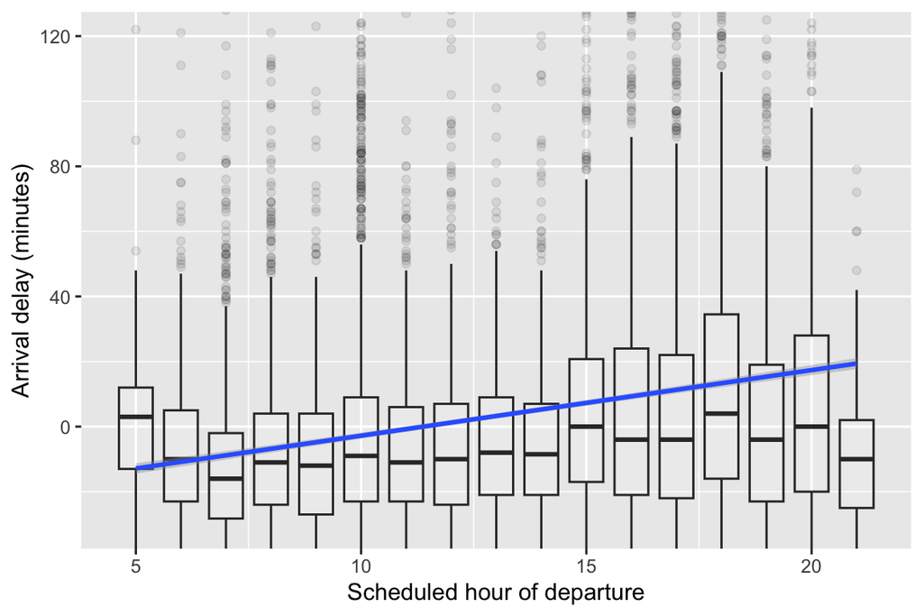

```r
SF %>%
  ggplot(aes(x = hour, y = arr_delay)) +
  geom_boxplot(alpha = 0.1, aes(group = hour)) +   # 연착 시간의 분포
  geom_smooth(method = "lm") +
  xlab("Scheduled hour of departure") +
  ylab("Arrival delay (minutes)") +
  coord_cartesian(ylim = c(-30, 120))
```

**Python**

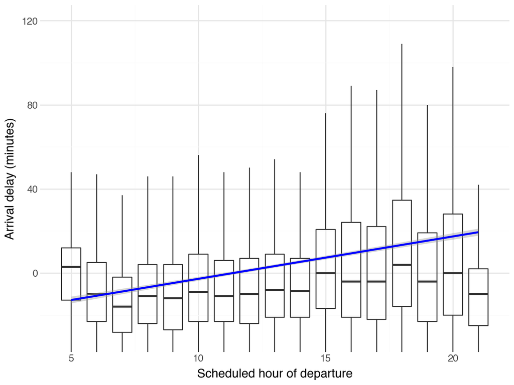

```python
(
    ggplot(SF, aes(x="hour", y="arr_delay"))
    + geom_boxplot(
        aes(group="hour"),
        alpha=0.1,
        outlier_alpha=0  # Hide outliers to match the visual focus of coord_cartesian
    )
    + geom_smooth(method="lm", color="blue")
    + labs(
        x="Scheduled hour of departure",
        y="Arrival delay (minutes)"
    )
    + coord_cartesian(ylim=(-30, 120))
    + theme_minimal()
).show()
```

- 평균 연착 시간은 하루 동안 시간이 지날수록 증가
- 추세선 자체는 선형회귀 모형으로 생성

**R**

```r
mod1 <- lm(arr_delay ~ hour, data = SF)
broom::tidy(mod1)
```

```
# A tibble: 2 × 5
  term        estimate std.error statistic   p.value
  <chr>          <dbl>     <dbl>     <dbl>     <dbl>
1 (Intercept)   -22.9     1.23       -18.6 2.88e- 76
2 hour            2.01    0.0915      22.0 1.78e-105
```

**Python**

```python
import statsmodels.formula.api as smf

model = smf.ols("arr_delay ~ hour", data=SF.to_pandas()).fit()
tidy_df = pl.from_pandas(
    model.summary2().tables[1].reset_index()
).rename({"index": "term", "Coef.": "estimate", "Std.Err.": "std_error", "t": "statistic", "P>|t|": "p_value"})

print(tidy_df)
```

```
shape: (2, 7)
┌───────────┬────────────┬───────────┬────────────┬─────────────┬────────────┬────────────┐
│ term      ┆ estimate   ┆ std_error ┆ statistic  ┆ p_value     ┆ [0.025     ┆ 0.975]     │
│ ---       ┆ ---        ┆ ---       ┆ ---        ┆ ---         ┆ ---        ┆ ---        │
│ str       ┆ f64        ┆ f64       ┆ f64        ┆ f64         ┆ f64        ┆ f64        │
╞═══════════╪════════════╪═══════════╪════════════╪═════════════╪════════════╪════════════╡
│ Intercept ┆ -22.932674 ┆ 1.232751  ┆ -18.602845 ┆ 2.8825e-76  ┆ -25.349043 ┆ -20.516304 │
│ hour      ┆ 2.014875   ┆ 0.091539  ┆ 22.011108  ┆ 1.7767e-105 ┆ 1.835445   ┆ 2.194304   │
└───────────┴────────────┴───────────┴────────────┴─────────────┴────────────┴────────────┘
```

- 이 모형은 실제 항공편의 도착이 시간대별로 2.0 ± 0.18 분씩 증가한다고 95%의 신뢰도로 이야기함
- 매우 작은 유의확률: 시간대와 항공편 지연 사이에 연관성이 없다면 이렇게 극단적인 결과가 나올 가능성이 매우 낮다는 것을 의미
- 항공편 지연을 설명하는 데 도움이 될 수 있는 추가 요인은 무엇이 있을까?
  - 출발 공항, 항공사, 연도, 월, 요일 등
  - 또한 6월과 7월이 지연이 긴 달이라는 사실에 대해 이미 알고 있음

**R**

```r
SF <- SF %>%
  mutate(
    day = as.Date(time_hour),
    dow = as.character(wday(day, label = TRUE)),  # day of the week
    season = ifelse(month %in% 6:7, "summer", "other month")
  )
mod2 <- lm(arr_delay ~ hour + origin + carrier + season + dow, data = SF)
```

**Python**

```python
import statsmodels.formula.api as smf

sf = SF.with_columns([
    pl.col("time_hour").str.to_datetime().alias("time_hour")
]).with_columns([
    pl.col("time_hour").cast(pl.Date).alias("day"),

    pl.col("time_hour").dt.weekday().map_elements(
        lambda d: ["Mon", "Tue", "Wed", "Thu", "Fri", "Sat", "Sun"][d-1],
        return_dtype=pl.String
    ).alias("dow"),

    pl.when(pl.col("month").is_in([6, 7]))
      .then(pl.lit("summer"))
      .otherwise(pl.lit("other month"))
      .alias("season")
])
formula = "arr_delay ~ hour + origin + carrier + season + dow"
mod2 = smf.ols(formula, data=sf.to_pandas()).fit()

print(mod2.summary().tables[1])
```

```
====================================================================================
                       coef    std err          t      P>|t|      [0.025      0.975]
------------------------------------------------------------------------------------
Intercept          -24.5408      2.175    -11.286      0.000     -28.803     -20.278
origin[T.JFK]        4.1989      1.004      4.180      0.000       2.230       6.168
carrier[T.B6]      -10.3322      1.880     -5.497      0.000     -14.017      -6.648
carrier[T.DL]      -18.4011      1.615    -11.396      0.000     -21.566     -15.236
carrier[T.UA]       -4.7825      1.481     -3.230      0.001      -7.685      -1.880
carrier[T.VX]       -5.0365      1.598     -3.152      0.002      -8.169      -1.904
season[T.summer]    25.3272      1.031     24.573      0.000      23.307      27.348
dow[T.Mon]           1.4438      1.444      1.000      0.318      -1.388       4.275
dow[T.Sat]          -5.9460      1.562     -3.807      0.000      -9.007      -2.885
dow[T.Sun]           5.5372      1.471      3.764      0.000       2.654       8.420
dow[T.Thu]           3.3359      1.446      2.307      0.021       0.501       6.170
dow[T.Tue]          -1.8487      1.450     -1.275      0.202      -4.691       0.994
dow[T.Wed]          -0.5014      1.449     -0.346      0.729      -3.342       2.339
hour                 2.0642      0.090     22.985      0.000       1.888       2.240
====================================================================================
```

**R**

```r
broom::tidy(mod2)
```

```
# A tibble: 14 × 5
   term         estimate std.error statistic   p.value
   <chr>           <dbl>     <dbl>     <dbl>     <dbl>
 1 (Intercept)   -24.6      2.17     -11.3   1.27e- 29
 2 hour            2.08     0.0898    23.2   1.44e-116
 3 originJFK       4.12     1.00       4.10  4.17e-  5
 4 carrierB6     -10.3      1.88      -5.49  4.07e-  8
 5 carrierDL     -18.4      1.62     -11.4   5.88e- 30
 6 carrierUA      -4.76     1.48      -3.21  1.31e-  3
 7 carrierVX      -5.06     1.60      -3.17  1.54e-  3
 8 seasonsummer   25.3      1.03      24.5   5.20e-130
 9 dowMon          1.74     1.45       1.20  2.28e-  1
10 dowSat         -5.60     1.55      -3.62  2.98e-  4
11 dowSun          5.12     1.48       3.46  5.32e-  4
12 dowThu          3.16     1.45       2.18  2.90e-  2
13 dowTue         -1.65     1.45      -1.14  2.53e-  1
14 dowWed         -0.884    1.45      -0.610 5.42e-  1
```

**Python**

```python
print(
    pl.from_pandas(mod2.summary2().tables[1].reset_index())
    .rename({
        "index": "term",
        "Coef.": "estimate",
        "Std.Err.": "std_error",
        "t": "statistic",
        "P>|t|": "p_value"
    })
)
```

```
shape: (14, 7)
┌───────────────┬────────────┬───────────┬────────────┬─────────────┬────────────┬────────────┐
│ term          ┆ estimate   ┆ std_error ┆ statistic  ┆ p_value     ┆ [0.025     ┆ 0.975]     │
│ ---           ┆ ---        ┆ ---       ┆ ---        ┆ ---         ┆ ---        ┆ ---        │
│ str           ┆ f64        ┆ f64       ┆ f64        ┆ f64         ┆ f64        ┆ f64        │
╞═══════════════╪════════════╪═══════════╪════════════╪═════════════╪════════════╪════════════╡
│ Intercept     ┆ -24.540814 ┆ 2.174513  ┆ -11.285661 ┆ 2.1083e-29  ┆ -28.803173 ┆ -20.278456 │
│ origin[T.JFK] ┆ 4.198892   ┆ 1.004416  ┆ 4.180431   ┆ 0.000029    ┆ 2.230091   ┆ 6.167692   │
│ carrier[T.B6] ┆ -10.332233 ┆ 1.879705  ┆ -5.496733  ┆ 3.9410e-8   ┆ -14.016725 ┆ -6.647741  │
│ carrier[T.DL] ┆ -18.40107  ┆ 1.614637  ┆ -11.396414 ┆ 6.0198e-30  ┆ -21.565992 ┆ -15.236149 │
│ carrier[T.UA] ┆ -4.782469  ┆ 1.480834  ┆ -3.229579  ┆ 0.001243    ┆ -7.685117  ┆ -1.879822  │
│ …             ┆ …          ┆ …         ┆ …          ┆ …           ┆ …          ┆ …          │
│ dow[T.Sun]    ┆ 5.537205   ┆ 1.470916  ┆ 3.76446    ┆ 0.000168    ┆ 2.653997   ┆ 8.420413   │
│ dow[T.Thu]    ┆ 3.335867   ┆ 1.446103  ┆ 2.306797   ┆ 0.021082    ┆ 0.501296   ┆ 6.170438   │
│ dow[T.Tue]    ┆ -1.848718  ┆ 1.450234  ┆ -1.274772  ┆ 0.202412    ┆ -4.691385  ┆ 0.99395    │
│ dow[T.Wed]    ┆ -0.501403  ┆ 1.449131  ┆ -0.346002  ┆ 0.729347    ┆ -3.341909  ┆ 2.339104   │
│ hour          ┆ 2.064231   ┆ 0.089808  ┆ 22.984869  ┆ 1.1788e-114 ┆ 1.888194   ┆ 2.240268   │
└───────────────┴────────────┴───────────┴────────────┴─────────────┴────────────┴────────────┘
```

- 적합된 계수(`estimate`)는 기준 그룹인 `EWR` 대신 `JFK`에서 출발하는 경우 평균 지연에 4.1분을 더해야 한다는 것을 알려줌.
- 델타항공은 다른 항공사보다 연착이 적음
- 6월과 7월(25분), 일요일(5분)에 평균적으로 지연 시간이 더 긺
  - 아시아나 착륙 사고가 7월
- 토요일은 평균 연착 시간보다 6분 짧음 (각 요일은 알파벳순으로 먼저 오기 때문에 기준 그룹으로 선택한 금요일과 비교)
- 표준 오차: 추정량의 정밀도를 알려줌
- 유의확률: 변수 간에 체계적인 연관성이 없더라도 개별 패턴이 우연히 발생할 것으로 예상되는 것과 일치할 확률
- 다른 모형: “항공편이 100분 이상 연착할 확률은 얼마나 될까?”

# 교락

## 다른 요인에 의한 설명

> 상관관계가 인과관계를 의미하지는 않는다.
- 상관관계가 인과 관계를 암시하는 경우가 많음 (임의화검정에서뿐만은 아님)
- 관측 연구에서의 주요 관심사는 두 요인 간의 겉보기 관계를 실제로 결정할 수 있는 다른 요인에 의해 실제 연관성이 왜곡되고 있는 것은 아닌지의 여부
  - 이들 요인은 조사 중인 상관(또는 인과)관계에 혼선을 줄 수 있음 (confounder, 교락)

## 임의화 검정

- 증거 기반 연구의 표준
- 온라인 업계에서는 A/B 테스트라고도 불림
- 일반적으로 처치의 효과를 비교하기 위해 수행(예: 두 가지 형태의 웹 페이지)
- 새로운 개입을 받는 사람과 대조군(또는 표준 처치)을 받는 사람을 통제함으로써 다른 모든 요인이 두 그룹 간에 평균적으로 균형을 이루도록 함
- 시험이 끝날 때 측정된 결과에 차이가 있는 경우, 이는 치료법의 적용에 기인한 것이라고 결론을 내릴 수 있음
- 주의: 피험자가 처치를 따르지 않거나 추적 관찰에서 사라지는 경우 임의화 검정도 교락을 일으킬 수 있음

## 관측 연구

- 실용성의 문제
  - 담배가 폐암을 유발하는지 여부를 확인하기 위해 일부 어린이에게는 담배를 피우고 다른 어린이에게는 담배를 피우지 않도록 무작위로 배정
  - 커피가 장기적으로 건강에 영향을 미치는지 확인하기 위해 성인을 무작위로 커피를 마시게 하거나 마시지 않게 함
- 관측 연구만이 중요한 질문에 답할 수 있는 유일한 방법일 수 있음
- 데이터과학자는 주로 관측자료로 작업

## 미국 수학능력시험(SAT) 자료

- 미국 50개 주의 평균 교사 급여(2010년 기준)와 평균 총 SAT 점수에 대한 관측 자료

> 교사 급여가 높을수록 주 차원에서 시험 결과가 더 좋은 것과 관련이 있을까? 그렇다면 시험 성적을 개선하기 위해 급여를 조정해야 하는가?

**R**

```r
SAT_2010 <- SAT_2010 %>%
  mutate(Salary = salary/1000)
SAT_plot <- ggplot(data = SAT_2010, aes(x = Salary, y = total)) +
  geom_point() +
  geom_smooth(method = "lm") +
  ylab("Average total score on the SAT") +
  xlab("Average teacher salary (thousands of USD)")
SAT_plot
```

**Python**

```python
SAT_2010 = pl.read_csv('data/SAT_2010.csv')

sat_2010 = SAT_2010.with_columns(
    (pl.col("salary") / 1000).alias("Salary")
)
sat_plot = (
    ggplot(sat_2010, aes(x="Salary", y="total"))
    + geom_point(alpha=0.7)
    + geom_smooth(method="lm", color="blue")
    + labs(
        y="Average total score on the SAT",
        x="Average teacher salary (thousands of USD)"
    )
)
sat_plot.show()
```

**R**

[figure not shown]

**Python**

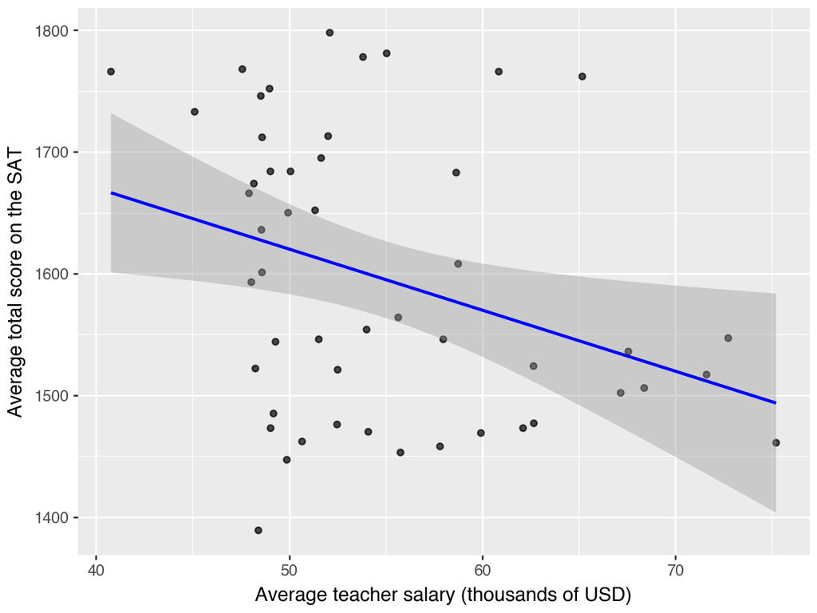

**R**

```r
SAT_mod1 <- lm(total ~ Salary, data = SAT_2010)
broom::tidy(SAT_mod1)
```

```
# A tibble: 2 × 5
  term        estimate std.error statistic  p.value
  <chr>          <dbl>     <dbl>     <dbl>    <dbl>
1 (Intercept)  1871.      113.       16.5  1.86e-21
2 Salary         -5.02      2.05     -2.45 1.79e- 2
```

**Python**

```python
import statsmodels.formula.api as smf

model_sat = smf.ols("total ~ Salary", data=sat_2010.to_pandas()).fit()
print(
    pl.from_pandas(model_sat.summary2().tables[1].reset_index())
    .rename({
        "index": "term",
        "Coef.": "estimate",
        "Std.Err.": "std_error",
        "t": "statistic",
        "P>|t|": "p_value"
    })
)
```

```
shape: (2, 7)
┌───────────┬───────────┬────────────┬───────────┬────────────┬───────────┬───────────┐
│ term      ┆ estimate  ┆ std_error  ┆ statistic ┆ p_value    ┆ [0.025    ┆ 0.975]    │
│ ---       ┆ ---       ┆ ---        ┆ ---       ┆ ---        ┆ ---       ┆ ---       │
│ str       ┆ f64       ┆ f64        ┆ f64       ┆ f64        ┆ f64       ┆ f64       │
╞═══════════╪═══════════╪════════════╪═══════════╪════════════╪═══════════╪═══════════╡
│ Intercept ┆ 1871.1037 ┆ 113.141235 ┆ 16.53777  ┆ 1.8628e-21 ┆ 1643.618  ┆ 2098.5894 │
│ Salary    ┆ -5.018956 ┆ 2.047537   ┆ -2.451217 ┆ 0.017929   ┆ -9.135804 ┆ -0.902108 │
└───────────┴───────────┴────────────┴───────────┴────────────┴───────────┴───────────┘
```

### 교락 요인

- 숨어 있는 또 다른 중요한 요소: 각 주에서 SAT를 치르는 학생의 비율은 매우 다양(2010년에는 3%에서 93%까지)

**R**

```r
SAT_2010 %>% skim(sat_pct)
```

**Variable type: numeric**

| var | n | na | mean | sd | p0 | p25 | p50 | p75 | p100 |
| --- | --- | --- | --- | --- | --- | --- | --- | --- | --- |
| sat_pct | 50 | 0 | 38.52 | 31.99 | 3 | 6 | 27 | 68 | 93 |

**Python**

```python
sat_2010.select("sat_pct").describe()
```

shape: (9, 2)

| statistic str | sat_pct f64 |
| --- | --- |
| "count" | 50.0 |
| "null_count" | 0.0 |
| "mean" | 38.52 |
| "std" | 31.991223 |
| "min" | 3.0 |
| "25%" | 6.0 |
| "50%" | 28.0 |
| "75%" | 68.0 |
| "max" | 93.0 |

- 주(state)를 두 그룹으로 나누는 `SAT_grp` 층화 변수를 만들자.

**R**

```r
SAT_2010 <- SAT_2010 %>%
  mutate(SAT_grp = ifelse(sat_pct <= 27, "Low", "High"))
SAT_2010 %>%
  group_by(SAT_grp) %>% count()
```

```
# A tibble: 2 × 2
# Groups:   SAT_grp [2]
  SAT_grp     n
  <chr>   <int>
1 High       25
2 Low        25
```

**Python**

```python
sat_2010 = sat_2010.with_columns(
    pl.when(pl.col("sat_pct") <= 27)
    .then(pl.lit("Low"))
    .otherwise(pl.lit("High"))
    .alias("SAT_grp")
)
print(
    sat_2010
    .group_by("SAT_grp")
    .agg(pl.len().alias("n"))
)
```

```
shape: (2, 2)
┌─────────┬─────┐
│ SAT_grp ┆ n   │
│ ---     ┆ --- │
│ str     ┆ u32 │
╞═════════╪═════╡
│ Low     ┆ 25  │
│ High    ┆ 25  │
└─────────┴─────┘
```

**R**

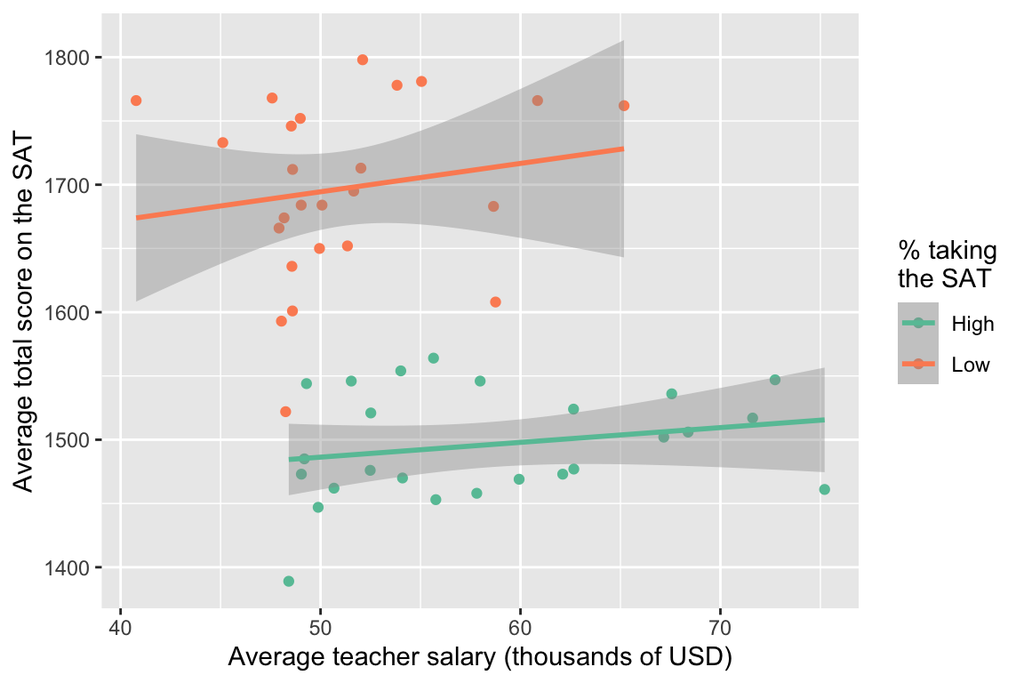

```r
SAT_plot %+% SAT_2010 +
  aes(color = SAT_grp) +
  scale_color_brewer("% taking\nthe SAT", palette = "Set2")
```

**Python**

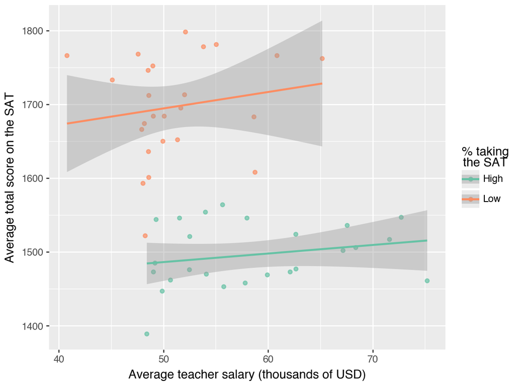

```python
(
    ggplot(sat_2010, aes(x="Salary", y="total", color="SAT_grp"))
    + geom_point(alpha=0.7)
    + geom_smooth(method="lm")
    + labs(
        y="Average total score on the SAT",
        x="Average teacher salary (thousands of USD)"
    )
    + scale_color_brewer(
        type="qual",
        palette="Set2",
        name="% taking\nthe SAT"
    )
).show()
```

- 7장의 반복법을 사용하여 두 개의 개별 그룹에 적합한 선형회귀 모형의 계수 도출

**R**

```r
SAT_2010 %>%
  group_by(SAT_grp) %>%
  group_modify(~broom::tidy(lm(total ~ Salary, data = .x)))
```

```
# A tibble: 4 × 6
# Groups:   SAT_grp [2]
  SAT_grp term        estimate std.error statistic  p.value
  <chr>   <chr>          <dbl>     <dbl>     <dbl>    <dbl>
1 High    (Intercept)  1428.       62.4     22.9   2.51e-17
2 High    Salary          1.16      1.06     1.09  2.85e- 1
3 Low     (Intercept)  1583.      141.      11.2   8.52e-11
4 Low     Salary          2.22      2.75     0.809 4.27e- 1
```

**Python**

```python
import statsmodels.formula.api as smf

def tidy_linear_model(df: pl.DataFrame):
    model = smf.ols("total ~ Salary", data=df.to_pandas()).fit()
    return (
        pl.from_pandas(model.summary2().tables[1].reset_index())
        .rename({
            "index": "term",
            "Coef.": "estimate",
            "Std.Err.": "std_error",
            "t": "statistic",
            "P>|t|": "p_value"
        })
    )
print(
    sat_2010
    .group_by("SAT_grp")
    .map_groups(tidy_linear_model)
)
```

```
shape: (4, 7)
┌───────────┬─────────────┬────────────┬───────────┬────────────┬─────────────┬─────────────┐
│ term      ┆ estimate    ┆ std_error  ┆ statistic ┆ p_value    ┆ [0.025      ┆ 0.975]      │
│ ---       ┆ ---         ┆ ---        ┆ ---       ┆ ---        ┆ ---         ┆ ---         │
│ str       ┆ f64         ┆ f64        ┆ f64       ┆ f64        ┆ f64         ┆ f64         │
╞═══════════╪═════════════╪════════════╪═══════════╪════════════╪═════════════╪═════════════╡
│ Intercept ┆ 1583.265572 ┆ 141.257821 ┆ 11.208339 ┆ 8.5209e-11 ┆ 1291.051507 ┆ 1875.479638 │
│ Salary    ┆ 2.223863    ┆ 2.750077   ┆ 0.808655  ┆ 0.427      ┆ -3.465104   ┆ 7.91283     │
│ Intercept ┆ 1428.375819 ┆ 62.404815  ┆ 22.888872 ┆ 2.5053e-17 ┆ 1299.281624 ┆ 1557.470014 │
│ Salary    ┆ 1.159223    ┆ 1.059635   ┆ 1.093983  ┆ 0.285288   ┆ -1.032799   ┆ 3.351244    │
└───────────┴─────────────┴────────────┴───────────┴────────────┴─────────────┴─────────────┘
```

### 심슨 역설

- 심슨 역설의 정량적 버전
  - SAT 응시 비율이 낮은 주에서는 교사 급여와 SAT 점수가 양의 상관관계를 보임
  - SAT 응시 비율이 높은 주에서는 교사 급여와 SAT 점수가 양의 상관관계를 보임
  - **응시 비율을 무시**하면 교사 급여와 SAT 점수가 음의 상관관계를 보임.
- 교락변수가 측정되는 경우 문제를 해결하는 것은 간단
  - 층화
  - 다중 회귀
- 회귀 모형에 `sat_pct` 변수를 예측 변수로 추가

**R**

```r
SAT_mod2 <- lm(total ~ Salary + sat_pct, data = SAT_2010)
broom::tidy(SAT_mod2)
```

```
# A tibble: 3 × 5
  term        estimate std.error statistic  p.value
  <chr>          <dbl>     <dbl>     <dbl>    <dbl>
1 (Intercept)  1589.      58.5       27.2  2.16e-30
2 Salary          2.64     1.15       2.30 2.62e- 2
3 sat_pct        -3.55     0.278    -12.8  7.11e-17
```

**Python**

```python
import statsmodels.formula.api as smf

model_sat_adj = smf.ols("total ~ Salary + sat_pct", data=sat_2010.to_pandas()).fit()

print(
    pl.from_pandas(model_sat_adj.summary2().tables[1].reset_index())
    .rename({
        "index": "term",
        "Coef.": "estimate",
        "Std.Err.": "std_error",
        "t": "statistic",
        "P>|t|": "p_value"
    })
)
```

```
shape: (3, 7)
┌───────────┬─────────────┬───────────┬────────────┬────────────┬─────────────┬─────────────┐
│ term      ┆ estimate    ┆ std_error ┆ statistic  ┆ p_value    ┆ [0.025      ┆ 0.975]      │
│ ---       ┆ ---         ┆ ---       ┆ ---        ┆ ---        ┆ ---         ┆ ---         │
│ str       ┆ f64         ┆ f64       ┆ f64        ┆ f64        ┆ f64         ┆ f64         │
╞═══════════╪═════════════╪═══════════╪════════════╪════════════╪═════════════╪═════════════╡
│ Intercept ┆ 1589.006518 ┆ 58.47071  ┆ 27.176111  ┆ 2.1590e-30 ┆ 1471.378623 ┆ 1706.634414 │
│ Salary    ┆ 2.636993    ┆ 1.148794  ┆ 2.295443   ┆ 0.026216   ┆ 0.325916    ┆ 4.948069    │
│ sat_pct   ┆ -3.5526     ┆ 0.278497  ┆ -12.756326 ┆ 7.1077e-17 ┆ -4.112863   ┆ -2.992336   │
└───────────┴─────────────┴───────────┴────────────┴────────────┴─────────────┴─────────────┘
```

- `sat_pct`를 통제했을 때 `Salary`의 기울기가 양수이고 통계적으로 유의
  - `SAT_grp`로 층화분석한 결과와 일치
- 교사 급여가 SAT 점수 상승의 원인이라고 단정할 수는 없음
  - 그러나 교락 요인을 고려한 후 관찰한 연관성은 그렇지 않은 연관성보다 더 신뢰할 수 있음
- 관측자료에서 의미를 찾으려 할 때는 관측된 연관성을 왜곡할 수 있는 잠재적인 교락 요인을 찾아내는 것이 중요

# 유의확률의 위험성

## 통계적 가설검정의 위험성

- 유의확률(p값)은 데이터의 패턴이 실제로 무작위 우연의 결과라는 귀무가설 하에서 통계량이 관찰된 통계량보다 더 극단적인 값으로 나타날 확률
- 항공사 데이터 예제
  - “예측 변수와 항공편 지연 사이에 연관성이 없다”
- SAT 성적과 연봉 예제
  - “실제(모집단) 회귀 계수(기울기)가 0”
- 통상적으로 유의확률이 유의수준(예: $\alpha$=0.05) 이하이면 귀무가설을 기각
- “전부 아니면 전무” 사고방식의 문제
  - 귀무가설이 참으로 설정된 세계를 시뮬레이션하여 유의확률 계산
  - 유의확률이 크면 데이터가 시뮬레이션과 일치함을 나타낸다.
  - 유의확률이 매우 작으면 시뮬레이션이 관찰된 패턴의 메커니즘을 설명하는 것과 관련이 없음을 의미
    - 이 수치만으로는 어떤 종류의 가설이 패턴과 관련성이 있는지 알기 어려움
  - “유의한 결과”는 귀무가설을 거부할 수 있다는 뜻 — 어떤 가설을 받아들여야 하는지는 알려주지 않음

## 미국 통계학회의 유의확률에 대한 성명서(Wasserstein and Lazar 2016)

- 유의확률은 데이터가 지정된 통계 모형과 얼마나 호환되지 않는지를 나타낼 수 있다.
- 유의확률은 연구 가설이 참일 확률이나 데이터가 무작위적인 우연에 의해 생성되었을 확률을 측정하지 않는다.
- 과학적 결론 또는 정책 결정은 유의확률이 특정 임계값을 통과했는지 여부에만 근거해서는 안 된다.
- 적절한 추론을 위해서는 완전한 보고와 투명성이 필요하다.
- 유의확률 또는 통계적 유의성은 효과의 크기나 결과의 중요성을 측정하는 것이 아니다.
- 유의확률은 그 자체로는 모형이나 가설에 대한 증거의 좋은 척도를 제공하지 않는다.

**Note**

- 항상 결정(귀무가설 기각 또는 기각 실패)만 보고하지 말고 실제 유의확률(또는 p <0.0001과 같은 문구)을 보고하라.
- 신뢰 구간은 종종 더 해석하기 쉬우므로 함께 보고하라.

## 다중 검정

- 분석에는 하나의 가설 검정이 아니라 수십 개 이상의 가설이 포함될 수 있음
- 이러한 상황에서는 유의수준이 낮아도 데이터와 귀무가설 사이의 불일치를 입증하지 못함
- 임의화검정에서는 주결과 및 보조 결과를 미리 지정 가능
  - 본페로니 보정 등
- 관찰연구에서는 사전 지정된 프로토콜이 없으므로 어떤 수준의 본페로니 보정이 적절한지 알기 어려움

## 갈림길의 정원 (Andrew Gelman)

http://www.stat.columbia.edu/~gelman/research/unpublished/p_hacking.pdf

- 대부분의 분석에는 최종 분석이 설정되기 전에 데이터 코딩, 중요한 요인 결정, 모형 상정 및 수정 등에 대한 많은 결정이 수반
- 데이터를 살펴보고 간결한 표현을 구성하는 작업이 포함
  - 연속형 예측 변수를 임의의 그룹으로 잘라 해당 예측 변수와 결과 간의 관계를 평가
  - 탐색적 자료분석 과정에서 특정 변수를 회귀 모형에 포함하거나 제외
- 다른 옵션보다 더 많은 신호(또는 더 작은 유의확률)를 산출하는 결정을 선택 — 귀무가설 기각 편향
- 임상시험: 분석 계획을 미리 지정하고 게시해야 하므로 갈림길의 정원 문제가 덜 일반적
- 대부분의 데이터과학 문제: 재현 가능한 결과에 대한 의문으로 이어질 수 있음